# modified implementation

Daniel DeCollo

2023-04-01

```r
#Clean Environment
rm(list = ls())

#Import Libraries
library(ggplot2)
library(data.table)
library(dplyr)
library(xgboost)
library(ROSE)
library(pROC)
library(caret)
```

## Get data

```r
season_2009 <- fread('./season_2009.csv')
season_2010 <- fread('./season_2010.csv')
season_2011 <- fread('./season_2011.csv')
season_2012 <- fread('./season_2012.csv')
season_2013 <- fread('./season_2013.csv')
season_2014 <- fread('./season_2014.csv')
season_2015 <- fread('./season_2015.csv')
season_2016 <- fread('./season_2016.csv')
season_2017 <- fread('./season_2017.csv')
season_2018 <- fread('./season_2018.csv')
season_2019 <- fread('./season_2019.csv')
season_2020 <- fread('./season_2020.csv')
season_2021 <- fread('./season_2021.csv')
```

## Preprocessing - superbowl winners

0 indicates that the team did not win the SuperBowl. For teams that win, the 0 is changed to a 1.

```r
#2009
season_2009$super_bowl_winner <- 0
season_2009$super_bowl_winner[season_2009$Teams == "Steelers"] <- 1

#2010
season_2010$super_bowl_winner <- 0
season_2010$super_bowl_winner[season_2010$Teams == "Saints"] <- 1

#2011
season_2011$super_bowl_winner <- 0
season_2011$super_bowl_winner[season_2011$Teams == "Packers"] <- 1

#2012
season_2012$super_bowl_winner <- 0
season_2012$super_bowl_winner[season_2012$Teams == "Giants"] <- 1

#2013
season_2013$super_bowl_winner <- 0
season_2013$super_bowl_winner[season_2013$Teams == "Ravens"] <- 1

#2014
season_2014$super_bowl_winner <- 0
season_2014$super_bowl_winner[season_2014$Teams == "Seahawks"] <- 1

#2015
season_2015$super_bowl_winner <- 0
season_2015$super_bowl_winner[season_2015$Teams == "Patriots"] <- 1

#2016
season_2016$super_bowl_winner <- 0
season_2016$super_bowl_winner[season_2016$Teams == "Broncos"] <- 1

#2017
season_2017$super_bowl_winner <- 0
season_2017$super_bowl_winner[season_2017$Teams == "Patriots"] <- 1

#2018
season_2018$super_bowl_winner <- 0
season_2018$super_bowl_winner[season_2018$Teams == "Eagles"] <- 1

#2019
season_2019$super_bowl_winner <- 0
season_2019$super_bowl_winner[season_2019$Teams == "Patriots"] <- 1

#2020
season_2020$super_bowl_winner <- 0
season_2020$super_bowl_winner[season_2020$Teams == "Chiefs"] <- 1

#2021
season_2021$super_bowl_winner <- 0
season_2021$super_bowl_winner[season_2021$Teams == "Buccaneers"] <- 1
```

## training/ testing data

Training: 2009 - 2014 Testing: 2015 - 2020 Validation: 2021

```r
#merge training data
training <- rbind(season_2009, season_2010, season_2011,
                 season_2012, season_2013, season_2014)

#join 2018-2020 for testing data
testing <- rbind(season_2015, season_2016, season_2017,
                 season_2018, season_2019, season_2020)

#Validation data
validation <- season_2021
```

First few rows of testing data

```r
head(testing)
```

```
##      Teams Wins Loses Ties win_percent total_points total_rushing_yards
## 1:   49ers    5    11    0      0.3125          238                1544
## 2:   Bears    6    10    0      0.3750          335                1851
## 3: Bengals   12     4    0      0.7500          419                1805
## 4:   Bills    8     8    0      0.5000          379                2432
## 5: Broncos   12     4    0      0.7500          355                1718
## 6:  Browns    3    13    0      0.1875          278                1529
##    total_passing_yards total_yards total_turnovers def_st_td first_downs
## 1:                3316        4860              17         2         261
## 2:                3663        5514              21         0         312
## 3:                3923        5728              17         2         324
## 4:                3343        5775              19         5         297
## 5:                3970        5688              31        11         314
## 6:                3782        5311              30         5         307
##    super_bowl_winner
## 1:                 0
## 2:                 0
## 3:                 0
## 4:                 0
## 5:                 0
## 6:                 0
```

## drop unused columns

Remove the team name.

```r
training <- training[,-'Teams']

testing <- testing[,-'Teams']
```

## training size

Display the data imbalance for the Superbowl winners. Only one team can win per season so there has to be an imbalance to start.

```r
#number of rows that indicate winning teams
table(training$super_bowl_winner == 1)
```

```
##
## FALSE  TRUE
##   186     6
```

## Percentage of minority observation

Only about 3% of the training data represents a SuperBowl winning team.

```r
sum(training$super_bowl_winner)/nrow(training)*100
```

```
## [1] 3.125
```

## Oversampling for data imbalance

The original training dataset was 192 row. With ROSE, we are able to add synthetic data to expand it. Our ROSE training dataset is 1000 rows. ROSE also allows us to address the data imbalance. Everytime a row is added to the data, there is a 50% chance that the row will represent a SuperBowl winning team.

```r
#desired length of training
n_train <- 1000

#probability of minority class being generated
p_minority <- 0.5

rose_training <- ROSE(as.factor(super_bowl_winner) ~ ., data  = training, N = n_train, p = p_minority, seed = 412)$data
```

## New training table

Almost 50% of our ROSE training data represents a SuperBowl winning teams.

```r
table(rose_training$super_bowl_winner == 1)
```

```
##
## FALSE  TRUE
##   506   494
```

## train model

We trained two models. The first model was trained using our original training data. It has 192 rows and 3.125% of the data represents a SuperBowl winning team.

The second model was trained with our ROSE training data. It has 1000 rows and 49.4% of the data represents a SuperBowl winning team.

### Backwards Selection - ROSE model

```r
int_only_model <- glm(super_bowl_winner ~ 1,
                      family = binomial,
                      data = rose_training)

full_model <- glm(super_bowl_winner ~  win_percent + total_points +
                    total_rushing_yards + total_passing_yards + total_yards +
                        total_turnovers + def_st_td + first_downs,
                  data = rose_training, family = binomial())

rose_model <- stats::step(object = full_model,
            scope = list(lower = int_only_model, upper = full_model),
            data = rose_training,
            direction = "backward")
```

```
## Start:  AIC=1130.84
## super_bowl_winner ~ win_percent + total_points + total_rushing_yards +
##     total_passing_yards + total_yards + total_turnovers + def_st_td +
##     first_downs
##
##                       Df Deviance    AIC
## - total_rushing_yards  1   1113.4 1129.4
## - total_yards          1   1113.5 1129.5
## - first_downs          1   1113.6 1129.6
## <none>                     1112.8 1130.8
## - total_turnovers      1   1116.2 1132.2
## - total_points         1   1118.2 1134.2
## - total_passing_yards  1   1125.1 1141.1
## - def_st_td            1   1137.5 1153.5
## - win_percent          1   1190.6 1206.6
##
## Step:  AIC=1129.42
## super_bowl_winner ~ win_percent + total_points + total_passing_yards +
##     total_yards + total_turnovers + def_st_td + first_downs
##
##                       Df Deviance    AIC
## - total_yards          1   1113.8 1127.8
## - first_downs          1   1114.2 1128.2
## <none>                     1113.4 1129.4
## - total_turnovers      1   1116.4 1130.4
## - total_points         1   1118.6 1132.6
## - total_passing_yards  1   1131.5 1145.5
## - def_st_td            1   1137.6 1151.6
## - win_percent          1   1190.8 1204.8
##
## Step:  AIC=1127.8
## super_bowl_winner ~ win_percent + total_points + total_passing_yards +
##     total_turnovers + def_st_td + first_downs
##
##                       Df Deviance    AIC
## - first_downs          1   1115.0 1127.0
## <none>                     1113.8 1127.8
## - total_turnovers      1   1117.1 1129.1
## - total_points         1   1119.8 1131.8
## - total_passing_yards  1   1134.6 1146.6
## - def_st_td            1   1138.3 1150.3
## - win_percent          1   1193.0 1205.0
##
## Step:  AIC=1127.05
## super_bowl_winner ~ win_percent + total_points + total_passing_yards +
##     total_turnovers + def_st_td
##
##                       Df Deviance    AIC
## <none>                     1115.0 1127.0
## - total_turnovers      1   1118.5 1128.5
## - total_points         1   1123.0 1133.0
## - def_st_td            1   1139.6 1149.6
## - total_passing_yards  1   1144.3 1154.3
## - win_percent          1   1200.0 1210.0
```

```r
original_model <- glm(super_bowl_winner ~ win_percent + total_points + total_passing_yards +
    total_turnovers + def_st_td,
                      data = training, family = binomial())
```

## Model Summary

```r
summary(original_model)
```

```
##
## Call:
## glm(formula = super_bowl_winner ~ win_percent + total_points +
##     total_passing_yards + total_turnovers + def_st_td, family = binomial(),
##     data = training)
##
## Deviance Residuals:
##     Min       1Q   Median       3Q      Max
## -0.6689  -0.2754  -0.1817  -0.1123   2.7557
##
## Coefficients:
##                       Estimate Std. Error z value Pr(>|z|)
## (Intercept)         -7.3710737  3.7778830  -1.951    0.051 .
## win_percent          6.0180347  4.0904784   1.471    0.141
## total_points         0.0001257  0.0115222   0.011    0.991
## total_passing_yards  0.0002820  0.0009965   0.283    0.777
## total_turnovers      0.0018400  0.0794185   0.023    0.982
## def_st_td           -0.1295670  0.1542011  -0.840    0.401
## ---
## Signif. codes:  0 '***' 0.001 '**' 0.01 '*' 0.05 '.' 0.1 ' ' 1
##
## (Dispersion parameter for binomial family taken to be 1)
##
##     Null deviance: 53.399  on 191  degrees of freedom
## Residual deviance: 47.093  on 186  degrees of freedom
## AIC: 59.093
##
## Number of Fisher Scoring iterations: 7
```

```r
summary(rose_model)
```

```
##
## Call:
## glm(formula = super_bowl_winner ~ win_percent + total_points +
##     total_passing_yards + total_turnovers + def_st_td, family = binomial(),
##     data = rose_training)
##
## Deviance Residuals:
##     Min       1Q   Median       3Q      Max
## -2.3418  -0.9231  -0.2430   1.0037   1.9303
##
## Coefficients:
##                       Estimate Std. Error z value Pr(>|z|)
## (Intercept)         -4.4446894  0.5661069  -7.851 4.12e-15 ***
## win_percent          3.7431481  0.4346040   8.613  < 2e-16 ***
## total_points         0.0027740  0.0009915   2.798  0.00515 **
## total_passing_yards  0.0005728  0.0001080   5.301 1.15e-07 ***
## total_turnovers     -0.0188771  0.0101318  -1.863  0.06244 .
## def_st_td           -0.0985369  0.0205167  -4.803 1.56e-06 ***
## ---
## Signif. codes:  0 '***' 0.001 '**' 0.01 '*' 0.05 '.' 0.1 ' ' 1
##
## (Dispersion parameter for binomial family taken to be 1)
##
##     Null deviance: 1386.2  on 999  degrees of freedom
## Residual deviance: 1115.1  on 994  degrees of freedom
## AIC: 1127.1
##
## Number of Fisher Scoring iterations: 4
```

## test model

Adds the probability for the team to win according to the two models.

```r
testing$prediction <- predict(original_model, newdata = testing, type = "response")

#test ROSE model
testing$rose_prediction <- predict(rose_model, newdata = testing, type = "response")
```

This is the probability generated from the first model. Blue dots represent the actual winners. Most of the points are under 25%, including all of the winners.

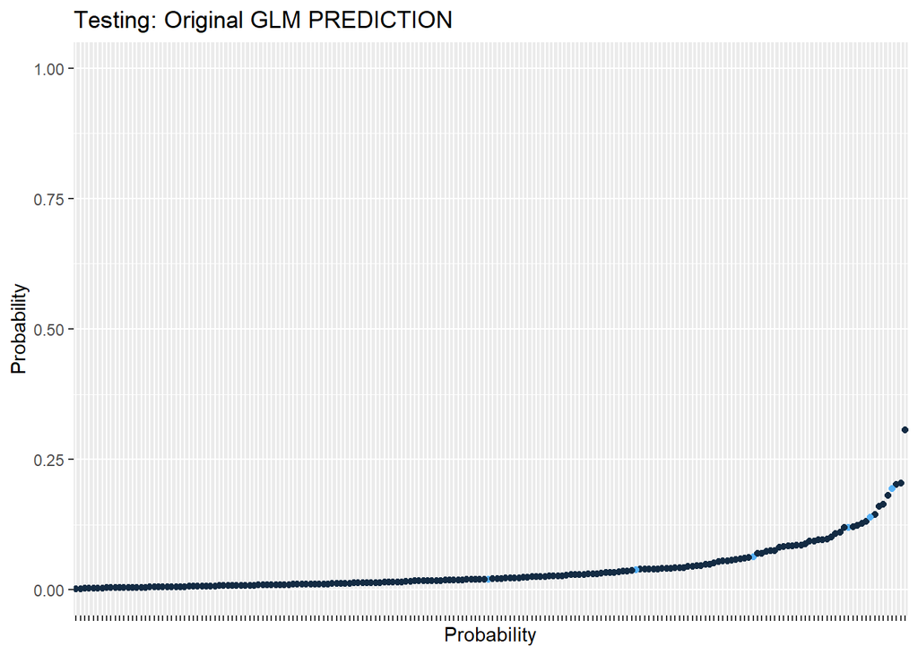

```r
#plot for original model
ggplot(testing, aes(x = reorder(prediction, prediction), y = prediction)) +
  geom_point(aes(colour = super_bowl_winner)) +
  ylim(0, 1) +
  theme(axis.text.x = element_text(angle = 90, vjust = 0.5)) +
  theme(legend.position = "none", axis.text.x = element_blank()) +
  xlab("Probability") +
  ylab("Probability")  +
  ggtitle("Testing: Original GLM PREDICTION")
```

This is the probability generated from the ROSE model. Blue dots represent the actual winners. The points distributed a little more and 5 out of 6 of the winners are above 50%. 3 out of 6 of the winners are above 75%.

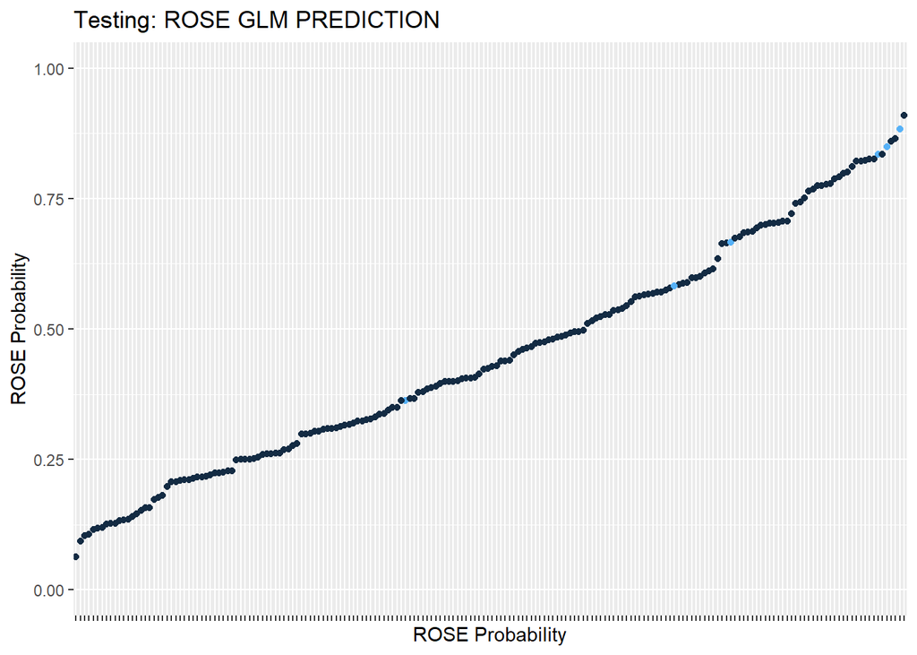

```r
#plot for original model
ggplot(testing, aes(x = reorder(rose_prediction, rose_prediction), y = rose_prediction)) +
  geom_point(aes(colour = super_bowl_winner)) +
  ylim(0, 1) +
  theme(axis.text.x = element_text(angle = 90, vjust = 0.5)) +
  theme(legend.position = "none", axis.text.x = element_blank()) +
  xlab("ROSE Probability")  +
  ylab("ROSE Probability")  +
  ggtitle("Testing: ROSE GLM PREDICTION")
```

## AUC

Original

```r
auc(testing$super_bowl_winner, testing$prediction)
```

```
## Area under the curve: 0.819
```

ROSE

```r
auc(testing$super_bowl_winner, testing$rose_prediction)
```

```
## Area under the curve: 0.8172
```

## Confusion Matrix

```r
threshold=0.50
temp <- testing %>% select(super_bowl_winner)
temp$predicted_values <- ifelse(testing$prediction>threshold,1,0)
temp$rose_predicted_values <- ifelse(testing$rose_prediction>threshold,1,0)

original_conf_matrix<-table(temp$predicted_values, temp$super_bowl_winner)
rose_conf_matrix<-table(temp$rose_predicted_values, temp$super_bowl_winner)
```

```r
original_conf_matrix
```

```
##
##       0   1
##   0 186   6
```

```r
#sensitivity
#sensitivity(original_conf_matrix)
```

ROSE Matrix

```r
rose_conf_matrix
```

```
##
##       0   1
##   0 117   1
##   1  69   5
```

```r
#sensitivity
sensitivity(rose_conf_matrix)
```

```
## [1] 0.6290323
```

## Validation

```r
validation$prediction <- predict(original_model, newdata = validation, type = "response")

#test ROSE model
validation$rose_prediction <- predict(rose_model, newdata = validation, type = "response")
```

With original model, if a team tied, then it could not win the superbowl

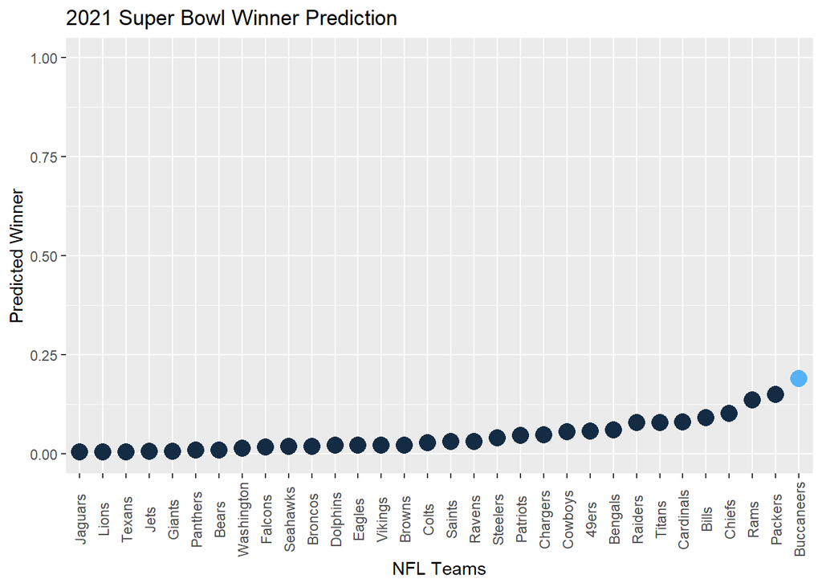

```r
ggplot(validation, aes(x = reorder(Teams, prediction), y = prediction)) +
  geom_point(aes(colour = super_bowl_winner, size = 1)) +
  theme(axis.text.x = element_text(angle = 90, vjust = 0.5)) +
  theme(legend.position = "none") +
  ylim(0, 1) +
  xlab("NFL Teams") +
  ylab("Predicted Winner") +
  ggtitle("2021 Super Bowl Winner Prediction")
```

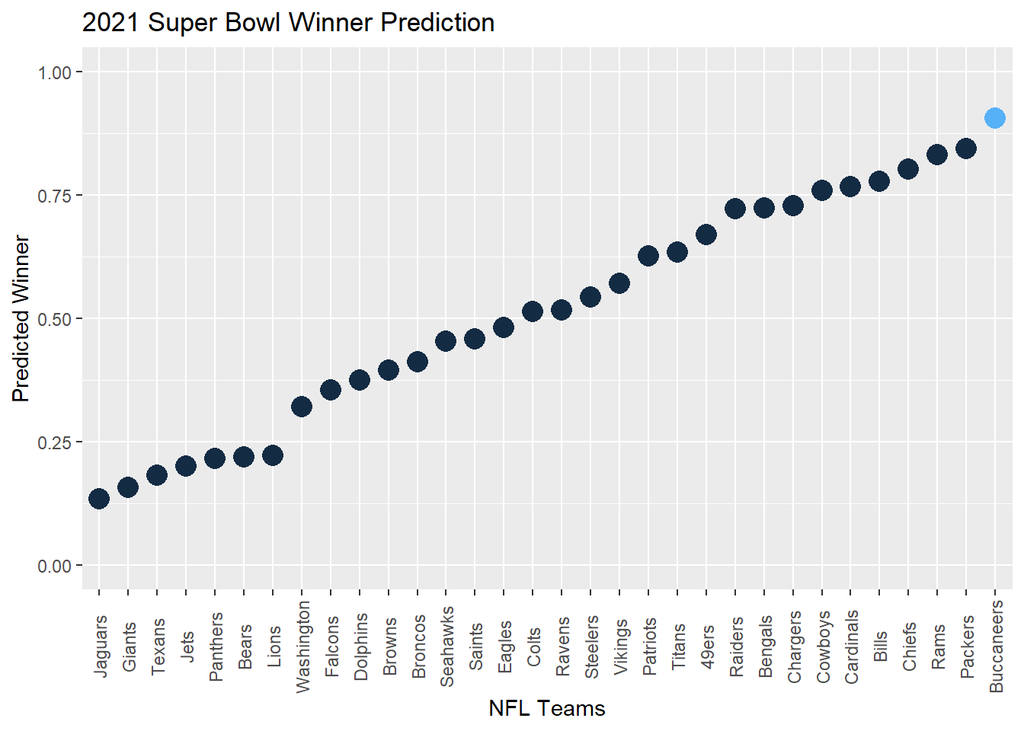

```r
ggplot(validation, aes(x = reorder(Teams, rose_prediction), y = rose_prediction)) +
  geom_point(aes(colour = super_bowl_winner, size = 1)) +
  theme(axis.text.x = element_text(angle = 90, vjust = 0.5)) +
  theme(legend.position = "none") +
  ylim(0, 1) +
  xlab("NFL Teams") +
  ylab("Predicted Winner") +
  ggtitle("2021 Super Bowl Winner Prediction")
```